# Moving out for a better career: Parental co-residence and later earnings

## Naive model

In the naive model, I explain a person’s earnings at the age of 30 with the number of years that they resided with their parents from age 18 to age 23.

$$\log(\text{income})_{i} = \beta_0 + \beta_1 \,\text{coresidence}_{i} +
\beta_2 X_{i} + \epsilon_{i}$$

where:

$\hat{\beta}_1$ is likely biased, because parental co-residence during college years is not random. More conscientious individuals, for example, may prefer to live with their parents and will also earn more later, on average.

```r
df_naive <- df %>%
  # filter(age >= 18 & age < 30) %>%
  filter(age >= 18 & age < 23) %>%
  group_by(pid) %>%
  summarize(coresidence = sum(coresidence, na.rm = TRUE), coresidence_sq = coresidence ** 2) %>%
  ungroup() %>%
  full_join(select(filter(df, age == 30), pid, income, age, educ)) %>%
  # mutate(
  #   experience = pmax(0, age - educ - 6),
  #   experience_sq = experience ^ 2
  # ) %>%
  drop_na()
```

```r
naive_models <- list(
  "(1) log(income)" = lm(income ~ coresidence, data = df_naive),
  "(2) log(income)" = lm(income ~ coresidence + coresidence_sq, data = df_naive),
  "(3) log(income)" = lm(income ~ coresidence + coresidence_sq + educ, data = df_naive)
)

modelsummary(
  models = naive_models,
  coef_map = c(
    income = "log(income)",
    coresidence = "co-residence",
    coresidence_sq = "(co-residence)^2",
    educ = "years of schooling",
    experience = "work experience",
    experience_sq = "(work experience)^2"
  ),
  gof_omit = "AIC|BIC|Log|RMSE",
  estimate  = "{estimate}{stars}",
  statistic = "({std.error})",
  stars = c('*' = .10, '**' = .05, '***' = .01)
)
```

|  | (1) log(income) | (2) log(income) | (3) log(income) |
| --- | --- | --- | --- |
| co-residence | 0.281*** | 0.637*** | 0.521*** |
|  | (0.029) | (0.121) | (0.119) |
| (co-residence)^2 |  | -0.069*** | -0.061*** |
|  |  | (0.023) | (0.022) |
| years of schooling |  |  | 0.253*** |
|  |  |  | (0.021) |
| Num.Obs. | 3845 | 3845 | 3845 |
| R2 | 0.024 | 0.026 | 0.061 |
| R2 Adj. | 0.024 | 0.026 | 0.060 |
| F | 94.340 | 51.855 | 82.661 |

## Effect of BAföG reforms on parental co-residence

## Simple difference-in-differences

$$\text{coresidence}_{i} = \alpha + \beta_1 \text{eligible}_i + \beta_2
\text{post}_t
+ \delta \left( \text{eligible}_i \times \text{post}_t \right) +
\varepsilon_{i}$$

where:

- $i$ is the individual;
- $\text{eligible}$ is whether the individual was eligible for BAfög
- $\text{coresidence}$ indicates whether the individual was living with their parents;
- $\text{post}_t$ is equal to 1 for observations in the period after the 2016 BAföG reform.

```r
estimation <- feols(coresidence ~ eligible * post, data = df_simple_did)

modelsummary(estimation,
             estimate  = "{estimate}{stars}",
            statistic = "({std.error})",
            stars = c('*' = .10, '**' = .05, '***' = .01))
```

|  | (1) |
| --- | --- |
| (Intercept) | 0.895*** |
|  | (0.015) |
| eligible | -0.191*** |
|  | (0.026) |
| Num.Obs. | 875 |
| R2 | 0.057 |
| R2 Adj. | 0.056 |
| AIC | 708.9 |
| BIC | 718.4 |
| RMSE | 0.36 |
| Std.Errors | IID |

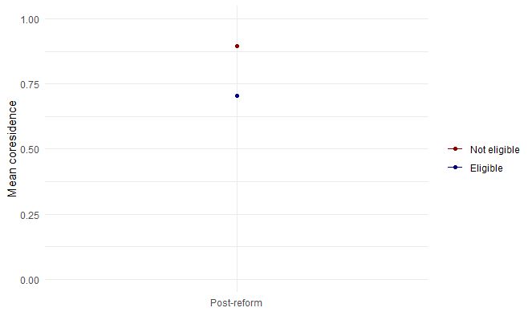

```r
df_simple_did %>%
  group_by(eligible, post) %>%
  summarize(mean_core = mean(coresidence, na.rm = TRUE)) %>%
  ungroup() %>%

  ggplot(aes(x = post, y = mean_core, group = eligible, color = factor(eligible))) +
  geom_line() +
  geom_point() +
  scale_color_manual(
    values = c("darkred", "darkblue"),
    labels = c("Not eligible", "Eligible")
  ) +
  scale_x_continuous(
    breaks = c(0, 1),
    labels = c("Pre-reform", "Post-reform")
  ) +
  labs(
    x = "",
    y = "Mean coresidence",
    color = ""
  ) +
  ylim(0, 1) +
  theme_minimal()
```

### Pre and post trends

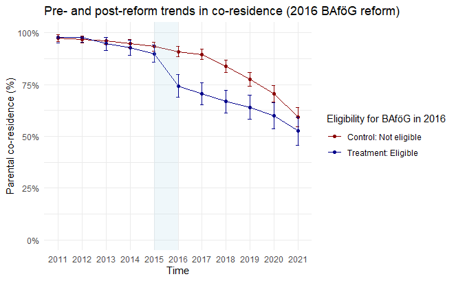

```r
treatment_group <- df_simple_did %>%
  filter(eligible == 1) %>%
  pull(pid)

control_group <- df_simple_did %>%
  filter(eligible == 0) %>%
  pull(pid)

trends <- df %>%
  select(pid, syear, age, student, coresidence, grant, parental_income) %>%
  filter(syear >= (2016 - 5) & syear <= (2016 + 5)) %>%
  filter(pid %in% c(treatment_group, control_group)) %>%
  mutate(treatment =
           case_when(
             pid %in% treatment_group ~ 1,
             pid %in% control_group ~ 0,
             .default = NA
           )) %>%
  filter(!is.na(treatment)) %>%
  group_by(syear, treatment) %>%
  summarize(
    mean_core = mean(coresidence, na.rm = TRUE),
    sd_core   = sd(coresidence, na.rm = TRUE),
    n         = sum(!is.na(coresidence)),
    se_core   = sd_core / sqrt(n),
    ci_low    = mean_core - 1.96 * se_core,
    ci_high   = mean_core + 1.96 * se_core
    ) %>%
  ungroup()

ggplot(trends, aes(x = syear, y = mean_core, color = factor(treatment))) +
  geom_line() +
  geom_point() +
  geom_errorbar(aes(ymin = ci_low, ymax = ci_high), width = 0.15) +
  annotate("rect",
           xmin = 2015, xmax = 2016,
           ymin = -Inf, ymax = Inf,
           alpha = 0.2, fill = "lightblue") +
  scale_color_manual(
    values = c("darkred", "darkblue"),
    labels = c("Control: Not eligible", "Treatment: Eligible")
  ) +
  scale_x_continuous(breaks = seq(min(df$syear), max(df$syear), by = 1), minor_breaks = NULL) +
  labs(
    title = "Pre- and post-reform trends in co-residence (2016 BAföG reform)",
    x = "Time",
    y = "Parental co-residence (%)",
    color = "Eligibility for BAföG in 2016"
  ) +
  scale_y_continuous(limits = c(0, 1), labels = percent) +
  theme_minimal()
```

```r
NA
```

# Appendix

## To do

- Construct a stacked difference-in-differences
- Expand on your theory: the clearer you make the relationship, the better you can estimate it (especially specificity tests and extensions)
- Add a fuzzy RD-design for parental income
- People who live at home may graduate more quickly, look into this
- Look at the change in income from age 23 to age 30 instead of the level at age 30
- Consider time preferences: SOEP includes this as self-assessed willingness to delay gratification
- Think of heterogeneity
- Look at geographic data, if possible

## Parental co-residence over time

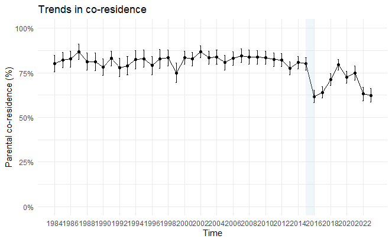

```r
df %>%
  select(pid, syear, age, student, coresidence, grant, parental_income) %>%
  filter(age == 20) %>%
  # filter(age >= 18 & age < 23) %>%
  group_by(syear) %>%
  summarize(
    mean_core = mean(coresidence, na.rm = TRUE),
    sd_core   = sd(coresidence, na.rm = TRUE),
    n         = sum(!is.na(coresidence)),
    se_core   = sd_core / sqrt(n),
    ci_low    = mean_core - 1.96 * se_core,
    ci_high   = mean_core + 1.96 * se_core
    ) %>%
  ungroup() %>%

  ggplot(aes(x = syear, y = mean_core)) +
  geom_line() +
  geom_point() +
  geom_errorbar(aes(ymin = ci_low, ymax = ci_high), width = 0.15) +
  annotate("rect",
           xmin = params$reform_year - 1, xmax = params$reform_year,
           ymin = -Inf, ymax = Inf,
           alpha = 0.2, fill = "lightblue") +
  scale_color_manual(
    values = c("darkred", "darkblue"),
    labels = c("Control: Not eligible", "Treatment: Eligible")
  ) +
  scale_x_continuous(breaks = seq(min(df$syear), max(df$syear), by = 2), minor_breaks = NULL) +
  labs(
    title = "Trends in co-residence",
    x = "Time",
    y = "Parental co-residence (%)"
  ) +
  scale_y_continuous(limits = c(0, 1), labels = percent) +
  theme_minimal()
```